# E-News Express Project

Description Background:

An online news portal aims to expand its business by acquiring new subscribers. Every visitor to the website takes certain actions based on their interest. The company plans to analyze these interests and wants to determine whether a new feature will be effective or not. Companies often analyze users' responses to two variants of a product to decide which of the two variants is more effective. This experimental technique is known as a/b testing that is used to determine whether a new feature attracts users based on a chosen metric.

Suppose you are hired as a Data Scientist in E-news Express. The design team of the company has created a new landing page. You have been assigned the task to decide whether the new landing page is more effective to gather new subscribers. Suppose you randomly selected 100 users and divided them equally into two groups. The old landing page is served to the first group (control group) and the new landing page is served to the second group (treatment group). Various data about the customers in both groups are collected in 'abtest.csv'. Perform the statistical analysis to answer the following questions using the collected data.

Objective:

Statistical analysis of business data. Explore the dataset and extract insights from the data. The idea is for you to get comfortable with doing statistical analysis in Python.

You are expected to perform the statistical analysis to answer the following questions:

- Explore the dataset and extract insights using Exploratory Data Analysis.
- Do the users spend more time on the new landing page than the old landing page?
- Is the conversion rate (the proportion of users who visit the landing page and get converted) for the new page greater than the conversion rate for the old page?
- Does the converted status depend on the preferred language? [Hint: Create a contingency table using the pandas.crosstab() function]
- Is the mean time spent on the new page same for the different language users?
- Consider a significance level of 0.05 for all tests.

Data Dictionary:

- user_id - This represents the user ID of the person visiting the website.
- group - This represents whether the user belongs to the first group (control) or the second group (treatment).
- landing_page - This represents whether the landing page is new or old.
- time_spent_on_the_page - This represents the time (in minutes) spent by the user on the landing page.
- converted - This represents whether the user gets converted to a subscriber of the news portal or not.
- language_preferred - This represents the language chosen by the user to view the landing page.

```python
# Import libraries
import numpy as np
import seaborn as sns
import pandas as pd
import matplotlib.pyplot as plt
import scipy.stats as stats
import warnings
warnings.filterwarnings('ignore')
```

```python
#Import Data File
data = pd.read_csv('abtest.csv')
```

## Exploratory Data Analysis

```python
#Take a look at the data
data.head()
```

|  | user_id | group | landing_page | time_spent_on_the_page | converted | language_preferred |
| --- | --- | --- | --- | --- | --- | --- |
| 0 | 546592 | control | old | 3.48 | no | Spanish |
| 1 | 546468 | treatment | new | 7.13 | yes | English |
| 2 | 546462 | treatment | new | 4.40 | no | Spanish |
| 3 | 546567 | control | old | 3.02 | no | French |
| 4 | 546459 | treatment | new | 4.75 | yes | Spanish |

```python
data.shape
```

```
(100, 6)
```

- 100 rows and 6 columns

```python
data.info()
data.isnull().sum()
```

```
<class 'pandas.core.frame.DataFrame'>
RangeIndex: 100 entries, 0 to 99
Data columns (total 6 columns):
 #   Column                  Non-Null Count  Dtype
---  ------                  --------------  -----
 0   user_id                 100 non-null    int64
 1   group                   100 non-null    object
 2   landing_page            100 non-null    object
 3   time_spent_on_the_page  100 non-null    float64
 4   converted               100 non-null    object
 5   language_preferred      100 non-null    object
dtypes: float64(1), int64(1), object(4)
memory usage: 4.8+ KB
```

```
user_id                   0
group                     0
landing_page              0
time_spent_on_the_page    0
converted                 0
language_preferred        0
dtype: int64
```

- 2 columns of numbers and 4 columns of categorical
- no missing values

```
The average customer spent 5.38 minutes on the landing page.
The minimum time spent on the landing page was 0.19 minutes.
The maximum time spent on the landing page was 10.71 minutes.
```

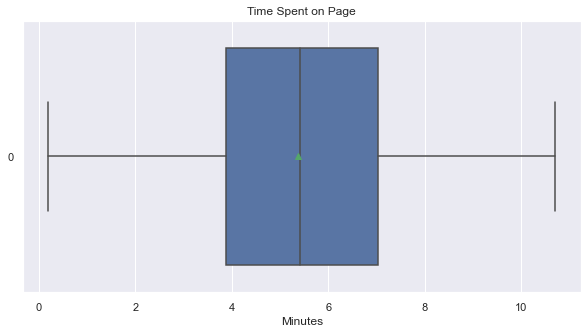

```python
# Explore time per page
sns.boxplot(data=data['time_spent_on_the_page'],orient="h",showmeans=True)
plt.xlabel("Minutes")

plt.title("Time Spent on Page")
time = data['time_spent_on_the_page'].mean()
print("The average customer spent",round(time,2),"minutes on the landing page.")
min_time = data['time_spent_on_the_page'].min()
max_time = data['time_spent_on_the_page'].max()
print("The minimum time spent on the landing page was", round(min_time,2),"minutes.")
print("The maximum time spent on the landing page was", round(max_time,2),"minutes.")
```

- No outliers present

```python
# Seperate and count 'group', 'converted', and 'language_preferred'
data['group'].value_counts()
```

```
control      50
treatment    50
Name: group, dtype: int64
```

- verified that control and treatment groups are evenly represented

```python
data['converted'].value_counts()
```

```
yes    54
no     46
Name: converted, dtype: int64
```

- more 'yes' than 'no' for converted customers

```python
# Function to create barplots that indicate percentage for each category.

def perc_on_bar(plot, feature):
    '''
    plot
    feature: categorical feature
    the function won't work if a column is passed in hue parameter
    '''
    total = len(feature) # length of the column
    for p in ax.patches:
        percentage = '{:.1f}%'.format(100 * p.get_height()/total) # percentage of each class of the category
        x = p.get_x() + p.get_width() / 2 - 0.05 # width of the plot
        y = p.get_y() + p.get_height()           # hieght of the plot
        ax.annotate(percentage, (x, y), size = 12) # annotate the percantage
    plt.show() # show the plot
```

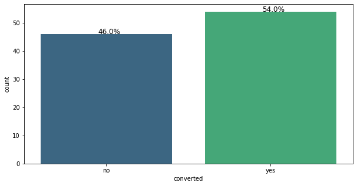

```python
# Plot conversion numbers
plt.figure(figsize=(10,5))
ax = sns.countplot(data["converted"],palette='viridis')
perc_on_bar(ax,data["converted"])
```

- 54% of the customers converted

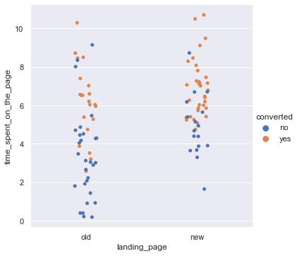

```python
#Landing_page vs time spent on the page
sns.catplot(x="landing_page", y="time_spent_on_the_page",hue='converted', data=data)
plt.figure(figsize=(10,5))
```

- Customers spent more time on the new page and the new page has a higher number of converted customers

```python
# Count Customers per Language
data['language_preferred'].value_counts()
```

```
Spanish    34
French     34
English    32
Name: language_preferred, dtype: int64
```

- All three languages are fairly equally represented

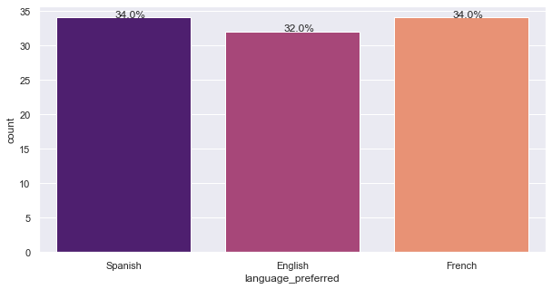

```python
# Plot Customers per Language
plt.figure(figsize=(10,5))
ax = sns.countplot(data["language_preferred"], palette = 'magma')
perc_on_bar(ax,data["language_preferred"])
```

- 3 languages, each almost evenly represented among the customers, with Spanish and French at 34% and English at 32%

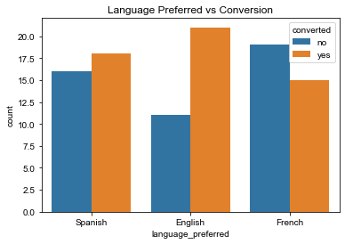

```python
#Graph language Preferred vs conversion
p = sns.countplot(x='language_preferred', hue ='converted', data = data)
p = sns.set(rc={'figure.figsize':(10,5)})
plt.title('Language Preferred vs Conversion')
```

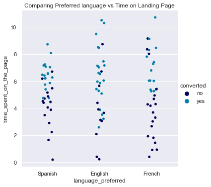

```python
# Time spent on the new page the same for different languages?
sns.catplot(x="language_preferred", y="time_spent_on_the_page",hue='converted', data=data, palette='ocean')
plt.title("Comparing Preferred language vs Time on Landing Page")
```

- Across all languages, the customers that spent the most time on the landing page converted
- English and French customers spent the longest on the landing page, compared to Spanish customers

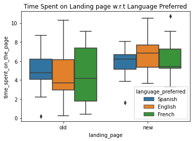

```python
# Graph time spent w.r.t language
a = sns.boxplot( x ='landing_page', y ='time_spent_on_the_page', data = data, hue ='language_preferred')
a.set_title("Time Spent on Landing page w.r.t Language Preferred")
plt.show()
```

# Inferential Statistics

- Continuous Data as time is measure on a continuous scale.
- Normally distributed as sample size is >30, Central Limit Theorem will hold true.
- Level of significance for all testing will be 0.05,
- Informed that the samples are a random sampling.

## Is the conversion rate for the new page greater than the old page rate?

### Define Null and Alternative Hypothesis

- Null Hypothesis : New Page is not more effective in converting customers
- - H<sub>0</sub>: $\mu_2 = \mu_1$
- Alternative Hypothesis: New Page has increased the conversion rate
- - H<sub>1</sub>: $\mu_2 > \mu_1$
- Let μ1 and μ2 be the mean output from the old landing page and the mean output from the new landing page respectively.
- n= 50 # each group has an n of 50 out of 100 customers sampled
- level of significance: 0.05

```python
# Quick check of conversion rates between old and new portal
# number of converted from old landing page
old = data[data['landing_page']=='old'].converted.value_counts()['yes']
old_df = pd.DataFrame(data[data['landing_page']=='old'])
# number of converted from new landing page
new = data[data['landing_page']=='new'].converted.value_counts()['yes']
new_df =pd.DataFrame(data[data['landing_page']=='new'])
# Conversion rate of control/treatment group
print("Landing page of old that converted:",old,",with a conversion rate of",round(old/50,2))
print("Landing page of new that converted:",new,",with a conversion rate of", round(new/50,2))
```

```
Landing page of old that converted: 21 ,with a conversion rate of 0.42
Landing page of new that converted: 33 ,with a conversion rate of 0.66
```

- 21 customers who went to the old landing page converted vs. the 33 customers who went to the new landing page
- Initially it appears that the new page has a higher conversion rate (0.66%) vs the old page (0.42%)
- is this difference truly statistically significant?

```python
# find the p-value using proportion_ztest
from statsmodels.stats.proportion import proportions_ztest
stat, pval = proportions_ztest([new,old] , [50, 50], alternative ='larger')

# print the p-value
print('The p-value is '+ str(pval))
```

```
The p-value is 0.008026308204056278
```

```python
# print the conclusion based on p-value
if pval < 0.05:
    print(f'As the p-value {pval} is less than the level of significance, we reject the null hypothesis.')
else:
    print(f'As the p-value {pval} is greater than the level of significance, we fail to reject the null hypothesis.')
```

```
As the p-value 0.008026308204056278 is less than the level of significance, we reject the null hypothesis.
```

## Conclusion

- We reject the null hypothesis
- Statistical evidence shows that new page does indeed increase the conversion rate compared to the old page at 0.05 level of significance

# Do the users spend more time on the new landing page than the old page?

### Step 1: Define null and alternative hypotheses

$H_0:$ users spend the same time on both pages

$H_a:$ users spend more time on the new landing page

We will test the null hypothesis

> $H_0:\mu_1=\mu_2$

against the alternate hypothesis

> $H_a:\mu_1<\mu_2$

```python
# time spent on each landing page
time_old_avg = data[data['landing_page']=='old'].time_spent_on_the_page.mean()
time_new_avg = data[data['landing_page']=='new'].time_spent_on_the_page.mean()
time_old_dev = data[data['landing_page']=='old'].time_spent_on_the_page.std()
time_new_dev = data[data['landing_page']=='new'].time_spent_on_the_page.std()
print("Average time spent on the old page:", round(time_old_avg,2),"minutes")
print("Average time spent on the new page:", round(time_new_avg,2),"minutes")
print("Standard Deviation for the old page:", round(time_old_dev,2),"minutes")
print("Standard Deviation for the new page:", round(time_new_dev,2),"minutes")
```

```
Average time spent on the old page: 4.53 minutes
Average time spent on the new page: 6.22 minutes
Standard Deviation for the old page: 2.58 minutes
Standard Deviation for the new page: 1.82 minutes
```

- initially it appears that customers spent more time on the new page
- Standard deviation is much larger for old landing page

```python
#Calculate p-Value
from numpy import sqrt, abs # import the required functions
from scipy.stats import norm # import the required function
def ztest_2samp(X1, X2, pop_sd1, pop_sd2, n1, n2):
    se = sqrt(pop_sd1**2/n1 + pop_sd2**2/n2) # calculate the standard error
    test_stat = ((X1.mean() - X2.mean()) - 0)/ se # calculate the test statistic
    pval = 1 - norm.cdf(abs(test_stat)) # calculate the one-tailed p-value
    return pval # return the p-value

p_value = ztest_2samp(data[data['landing_page']=='old'].time_spent_on_the_page,data[data['landing_page']=='new'].time_spent_on_the_page, 2.58, 1.82, 50 ,50)
print('The P-value is', p_value)
```

```
The P-value is 7.634426865454902e-05
```

### Conclusion

As the p-value is much less than the level of significance of 0.05, we reject the null hypothesis. Thus, we have enough statistical evidence to say that users spend more time on the new landing page vs. the old landing page

### Does language affect whether customers convert?

## Step 1: Define null and alternative hypotheses

$H_0:$ converted status is independent on preferred language

$H_a:$ converted status is dependent on preferred language

```python
#Does converted status depend on language?
pd.crosstab(data.language_preferred,data.converted)
```

| converted language_preferred | no | yes |
| --- | --- | --- |
| English | 11 | 21 |
| French | 19 | 15 |
| Spanish | 16 | 18 |

```python
# use chi2_contingency() to find the p-value
from   scipy.stats import chi2_contingency
language = pd.crosstab(data.language_preferred,data.converted)

chi2, pval, dof, exp_freq = chi2_contingency(language)
# print the p-value
print('The p-value is', pval)
```

```
The p-value is 0.2129888748754345
```

```python
if pval < 0.05:
    print(f'As the p-value {pval} is less than the level of significance, we reject the null hypothesis.')
else:
    print(f'As the p-value {pval} is greater than the level of significance, we fail to reject the null hypothesis.')
```

```
As the p-value 0.2129888748754345 is greater than the level of significance, we fail to reject the null hypothesis.
```

## Conclusion:

- as the p-value is greater than the level of significance (0.05), we fail to reject the null hypothesis.
- There is not sufficient statistical evidence to show that customer conversion is dependent on preferred language.

## Time Spent on landing page is the same for all languages

## Step 1: Define null and alternative hypotheses

$H_0:$ time spent on new landing page is the same for all languages

$H_a:$ at least one language has a different mean time

Let $\mu_1, \mu_2, \mu_3$ be the mean time on new landing page for English,French and Spanish.

We will test the null hypothesis

> $H_0: \mu_1 = \mu_2 = \mu_3$

against the alternative hypothesis

> $H_a: $ At least one language has a different mean time.

```python
# Time spent on landing page across different languages
data.groupby(["converted","language_preferred"]).agg({'time_spent_on_the_page': ['mean', 'min', 'max']})
```

| converted | language_preferred | time_spent_on_the_page mean | time_spent_on_the_page min | time_spent_on_the_page max |
| --- | --- | --- | --- | --- |
| no | English | 3.810909 | 0.22 | 8.73 |
|  | French | 3.861579 | 0.40 | 9.15 |
|  | Spanish | 4.052500 | 0.19 | 6.70 |
| yes | English | 6.474762 | 2.58 | 10.50 |
|  | French | 7.016000 | 5.25 | 10.71 |
|  | Spanish | 6.468889 | 4.75 | 8.72 |

- For all languages customers that converted spent more time on the landing page
- French converted customers spent the most time on the landing page, followed by English and Spanish

```python
# Mean time spent on new page across languages
data.groupby(["landing_page","language_preferred"]).agg({'time_spent_on_the_page': ['mean', 'min', 'max']})
```

| landing_page | language_preferred | time_spent_on_the_page mean | time_spent_on_the_page min | time_spent_on_the_page max |
| --- | --- | --- | --- | --- |
| new | English | 6.663750 | 3.65 | 10.50 |
|  | French | 6.196471 | 3.30 | 10.71 |
|  | Spanish | 5.835294 | 1.65 | 8.08 |
| old | English | 4.454375 | 0.22 | 10.30 |
|  | French | 4.310000 | 0.40 | 9.15 |
|  | Spanish | 4.828235 | 0.19 | 8.72 |

- The mean time spent on the new landing page across the languages is very close:
  - English at 6.7 minutes
  - French at 6.2 minutes
  - Spanish at 5.8 minutes
- The customers spent more time on the new page across all languages compared to the old page

```python
#Make new dataframe with only new landing page to test on
data2 = data.loc[(data['landing_page']=='new')]
data2
```

|  | user_id | group | landing_page | time_spent_on_the_page | converted | language_preferred |
| --- | --- | --- | --- | --- | --- | --- |
| 1 | 546468 | treatment | new | 7.13 | yes | English |
| 2 | 546462 | treatment | new | 4.40 | no | Spanish |
| 4 | 546459 | treatment | new | 4.75 | yes | Spanish |
| 6 | 546448 | treatment | new | 5.25 | yes | French |
| 8 | 546461 | treatment | new | 10.71 | yes | French |
| 12 | 546491 | treatment | new | 5.86 | yes | Spanish |
| 13 | 546478 | treatment | new | 6.03 | yes | French |
| 15 | 546466 | treatment | new | 6.27 | yes | Spanish |
| 16 | 546443 | treatment | new | 8.73 | no | English |
| 22 | 546450 | treatment | new | 3.65 | no | English |
| 23 | 546475 | treatment | new | 7.02 | yes | English |
| 24 | 546456 | treatment | new | 6.18 | no | Spanish |
| 25 | 546455 | treatment | new | 4.39 | no | English |
| 26 | 546469 | treatment | new | 9.49 | yes | English |
| 28 | 546471 | treatment | new | 7.81 | yes | French |
| 30 | 546464 | treatment | new | 5.41 | yes | English |
| 38 | 546487 | treatment | new | 1.65 | no | Spanish |
| 42 | 546489 | treatment | new | 7.16 | yes | Spanish |
| 43 | 546453 | treatment | new | 7.16 | yes | English |
| 44 | 546488 | treatment | new | 3.91 | no | English |
| 46 | 546460 | treatment | new | 5.37 | yes | French |
| 47 | 546458 | treatment | new | 7.23 | yes | Spanish |
| 48 | 546492 | treatment | new | 8.08 | yes | Spanish |
| 49 | 546473 | treatment | new | 10.50 | yes | English |
| 51 | 546457 | treatment | new | 5.65 | no | English |
| 52 | 546479 | treatment | new | 6.47 | yes | Spanish |
| 54 | 546482 | treatment | new | 6.41 | yes | Spanish |
| 57 | 546454 | treatment | new | 8.30 | yes | French |
| 60 | 546470 | treatment | new | 6.01 | yes | French |
| 61 | 546467 | treatment | new | 6.79 | yes | French |
| 65 | 546445 | treatment | new | 7.27 | yes | French |
| 68 | 546484 | treatment | new | 6.70 | no | Spanish |
| 71 | 546476 | treatment | new | 5.42 | yes | French |
| 72 | 546452 | treatment | new | 5.08 | yes | English |
| 73 | 546444 | treatment | new | 7.46 | yes | English |
| 77 | 546485 | treatment | new | 3.88 | no | Spanish |
| 78 | 546486 | treatment | new | 9.12 | yes | French |
| 80 | 546490 | treatment | new | 4.68 | no | French |
| 81 | 546449 | treatment | new | 5.26 | yes | French |
| 82 | 546463 | treatment | new | 5.74 | yes | Spanish |
| 86 | 546465 | treatment | new | 6.71 | no | English |
| 87 | 546480 | treatment | new | 3.68 | no | French |
| 88 | 546447 | treatment | new | 3.30 | no | French |
| 90 | 546477 | treatment | new | 5.40 | no | French |
| 91 | 546451 | treatment | new | 8.47 | yes | English |
| 93 | 546474 | treatment | new | 4.94 | no | French |
| 95 | 546446 | treatment | new | 5.15 | no | Spanish |
| 97 | 546472 | treatment | new | 7.07 | yes | Spanish |
| 98 | 546481 | treatment | new | 6.20 | yes | Spanish |
| 99 | 546483 | treatment | new | 5.86 | yes | English |

### Find the p-Value

```python
#import the required function
from scipy.stats import f_oneway

# perform one-way anova test
test_stat, p_value = f_oneway(data2.loc[data2['language_preferred'] == 'English', 'time_spent_on_the_page'],
                              data2.loc[data2['language_preferred'] == 'French', 'time_spent_on_the_page'],
                              data2.loc[data2['language_preferred'] == 'Spanish', 'time_spent_on_the_page'])
print('The p-value is ' + str(p_value))
```

```
The p-value is 0.43204138694325955
```

### Conclusion

Since the p-value is so large, we fail to reject the null hypothesis.  
There is not enough statistical evidence to conclude that at least one language mean time on the new page is statistically different from the rest at 5% significance level.